# Презентация по лабораторной работе №5

Дисциплина: Моделирование сетей передачи данных

Лобанова П.И.

Российский университет дружбы народов, Москва, Россия

16 сентября 2025

# Информация

## Докладчик

- Лобанова Полина Иннокентьевна
- Учащаяся на направлении “Фундаментальная информатика и информационные технологии”
- Студентка группы НФИбд-02-22
- polla-2004@mail.ru

# Цель

Основной целью работы является получение навыков проведения интерактивных экспериментов в среде Mininet по исследованию параметров сети, связанных с потерей, дублированием, изменением порядка и повреждением пакетов при передаче данных. Эти параметры влияют на производительность протоколов и сетей.

# Задание

1. Задайте простейшую топологию, состоящую из двух хостов и коммутатора с назначенной по умолчанию mininet сетью 10.0.0.0/8.
2. Проведите интерактивные эксперименты по по исследованию параметров сети, связанных с потерей, дублированием, изменением порядка и повреждением пакетов при передаче данных.
3. Реализуйте воспроизводимый эксперимент по добавлению правила отбрасывания пакетов в эмулируемой глобальной сети. На экран выведите сводную информацию о потерянных пакетах.
4. Самостоятельно реализуйте воспроизводимые эксперименты по исследованию параметров сети, связанных с потерей, изменением порядка и повреждением пакетов при передаче данных. На экран выведите сводную информацию о потерянных пакетах.

# Выполнение

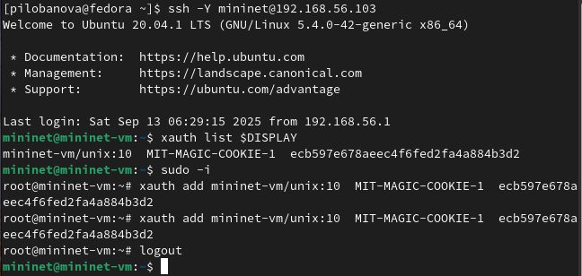

*Изменение прав запуска X-соединения.*

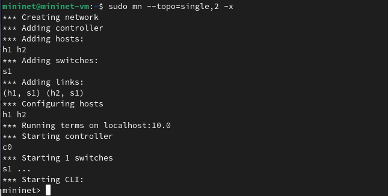

*Создание топологии*

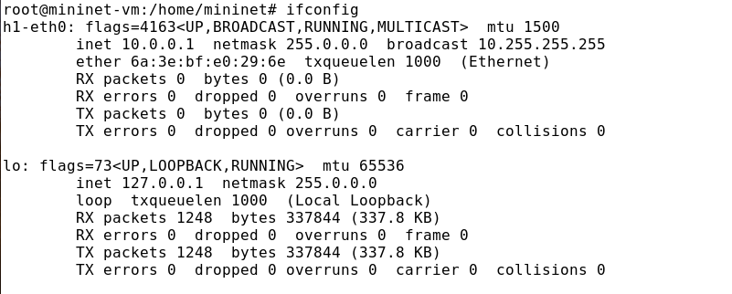

*Команда ifconfig на хосте h1*

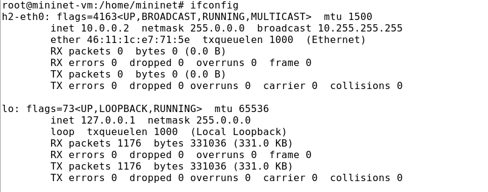

*Команда ifconfig на хосте h2*

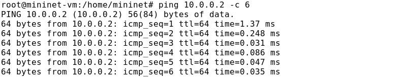

*Пингование*

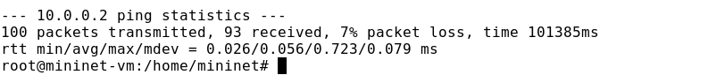

*Пингование*

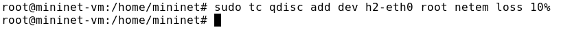

*Добавление процента потерь*

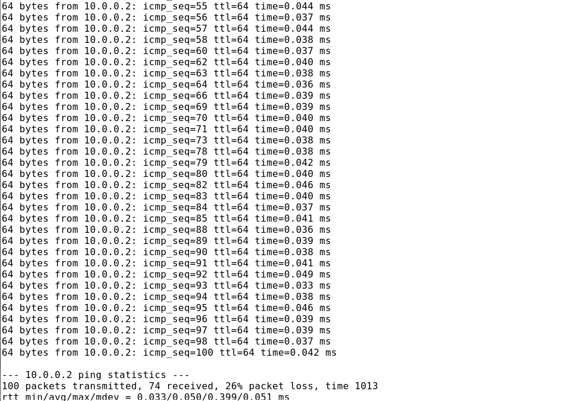

*Пингование*

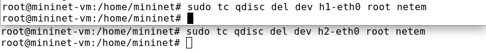

*Восстановление конфигурации*

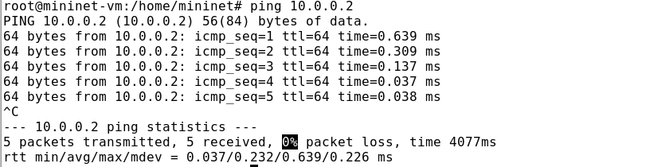

*Пингование*

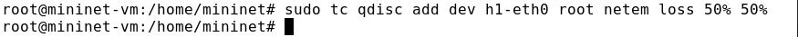

*Добавление коэффициента потерь с корреляцией*

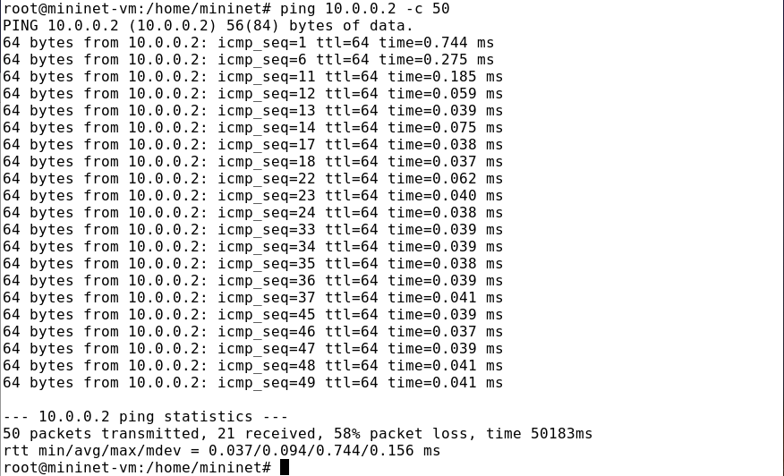

*Пингование*

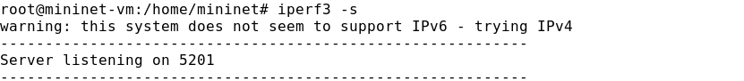

*Запуск сервера*

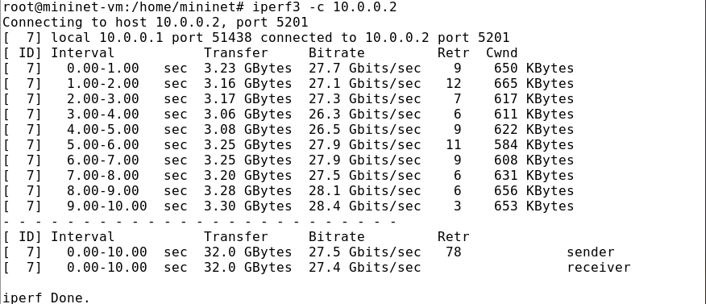

*Запуск клента*

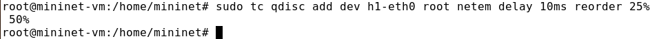

*Добавление переупорядочивания пакетов*

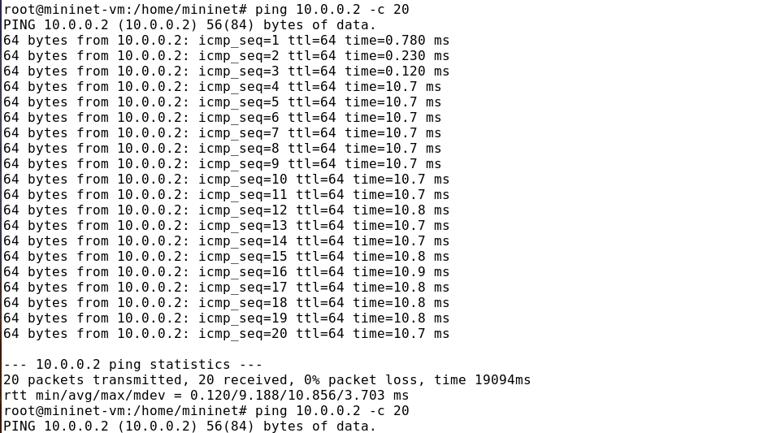

*Пингование*

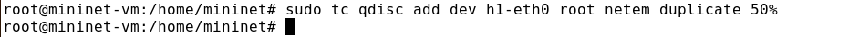

*Добавление дублирования*

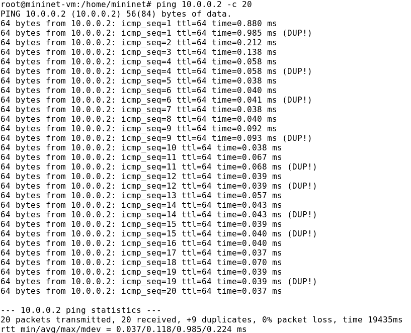

*Пингование*

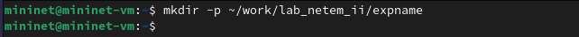

*Создание каталога*

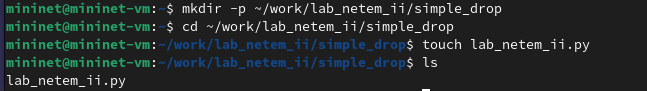

*Создание подкаталога*

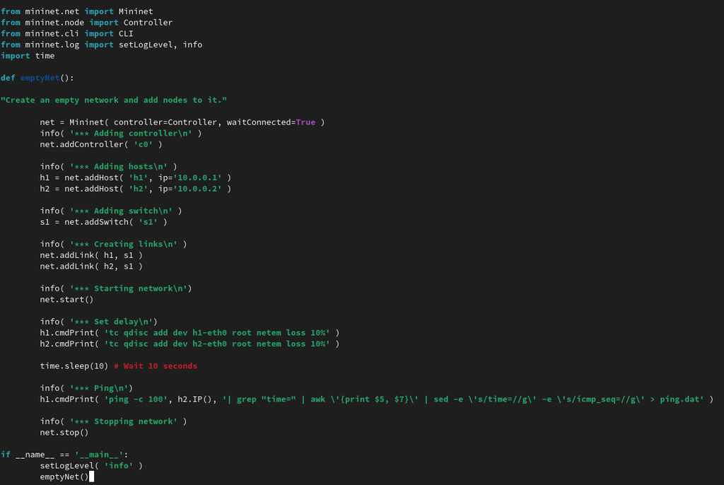

*Скрипт lab_netem_ii.py*

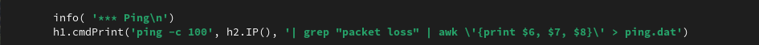

*Изменение в скрипте lab_netem_ii.py*

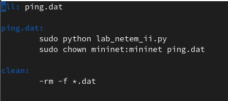

*Создание Makefile*

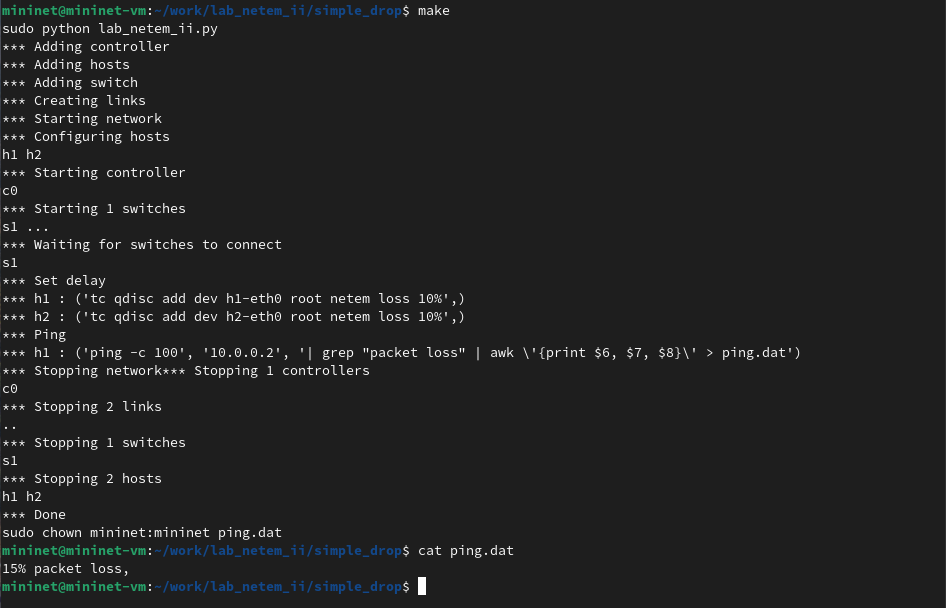

*Выполнение эксперимента*

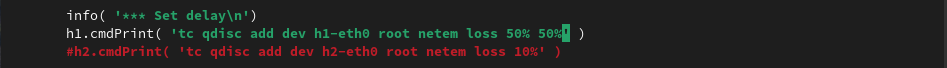

*Добавление коэффициента потерь с корреляцией*

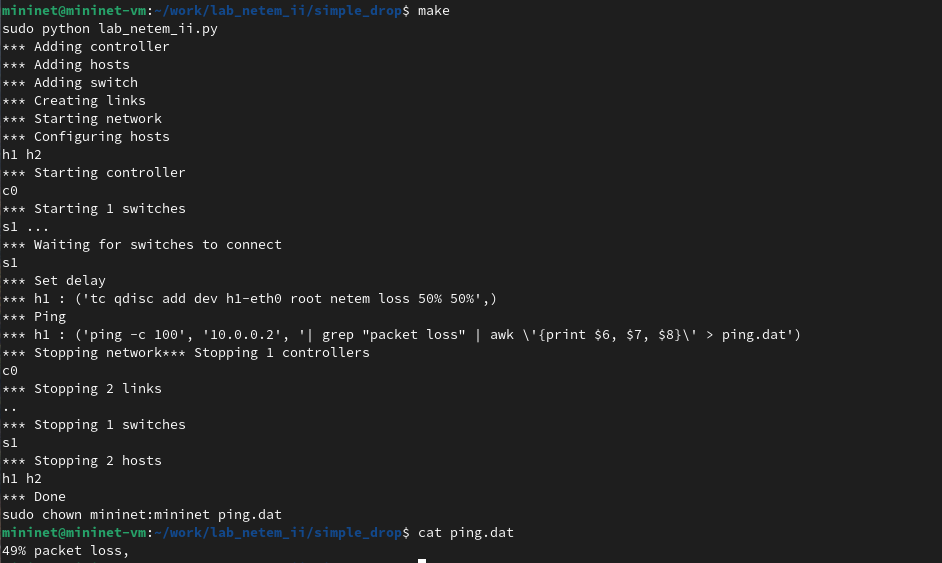

*Выполнение эксперимента*

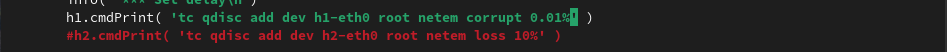

*Добавление повреждения*

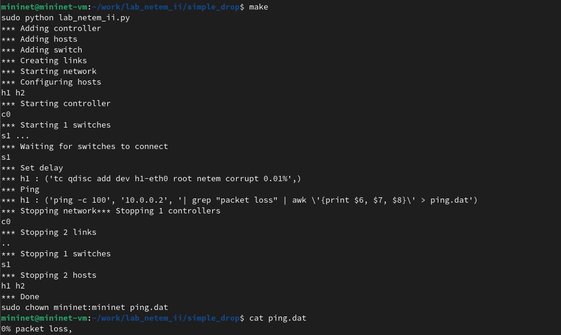

*Выполнение эксперимента*

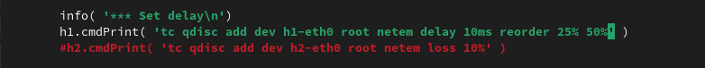

*Добавление переупорядочивания пакетов*

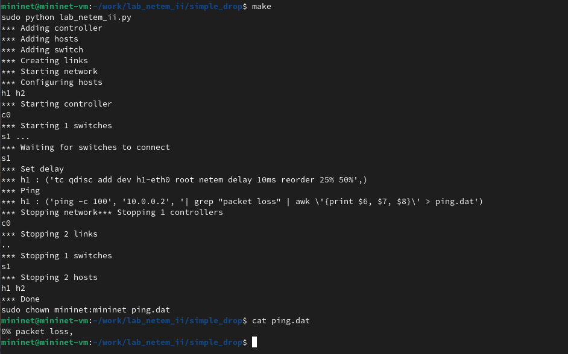

*Выполнение эксперимента*

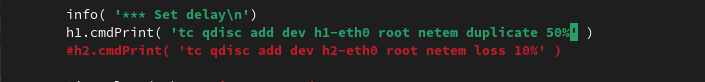

*Добавление дублирования*

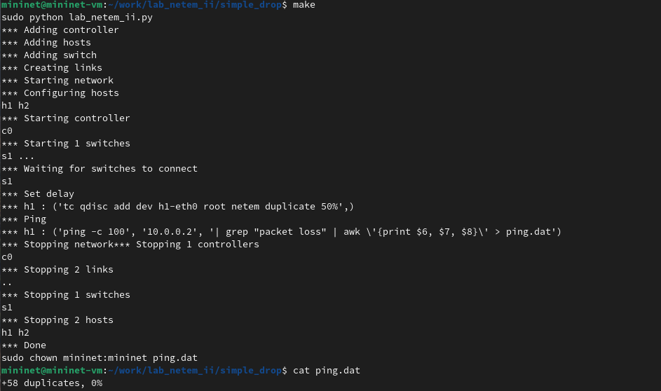

*Выполнение эксперимента*

# Вывод

Я получила навыки проведения интерактивных экспериментов в среде Mininet по исследованию параметров сети, связанных с потерей, дублированием, изменением порядка и повреждением пакетов при передаче данных.